# Working with NEON data on mobile devices

Matthew Aiello-Lammens

# Overview

In this activity, you will be introduced to some basic data processing and exploration steps using data from the National Ecological Observatory Network (NEON). You can learn more about NEON at this website - https://www.neonscience.org/. This activity is designed so that you can complete it using a mobile device, such as your phone, in conjunction with RStudio Cloud, https://rstudio.cloud/. Throughout the first part of the activity, we will work with the NEON **Plant Presence and Percent Cover** data set. More details on these data can be found here - https://data.neonscience.org/data-products/DP1.10058.001.

# Learning Objectives

By completing this activity, you should be able to:

## Quantitative / Data Skills

- explain the importance of data management in the scientific process
- modify a data set using a `data.frame` object in R
- modify `dplyr` code to summerise a data set
- calculate plot-level species richness values

## Concept learning objectives

- interpret data visualizations, such as histograms
- develop hypotheses related to differences in plant species richness among NEON sites

# Preliminaries

## Starting your RStudio session

In order to carry out the analyses in this activity, you will first need to initate a new R session. If you are on a desktop computer with RStudio installed, start a new RStudio session. (**NOTE: In this activity, I am not being careful in distiguishing R and RStudio. Strictly speaking, this is poor practice. R is the computer programming language and RStudio is an Integrated Development Environment that makes using R easier. You need to have both programs installed on your desktop.**) If you do not have RStudio installed, or you are working on a mobile device, you can sign-up for a free RStudio Cloud account, where you can run an RStudio session through a browser. Go to https://rstudio.cloud/ to begin this process.

## Getting our Rmd file

Next, let’s get the Rmd file that will allow us to run all of the code for this activity. This Rmd file is also the file that translates into this webpage! (Yes, that’s meta.) We will use the `download.file` function to get this Rmd file. You will need to copy and paste this line in your RStudio session.

```r
download.file("https://github.com/mlammens/NEONonMobile/raw/master/working-with-neon.Rmd",
              destfile = "./temp.Rmd")
```

## Install and load a few packages into your R environment

```r
install.packages("dplyr")
install.packages("ggplot2")
install.packages("neonUtilities")
```

Load packages

```r
library(neonUtilities)
library(dplyr)
```

```r
library(ggplot2)

# Set global option to NOT convert all character variables to factors
options(stringsAsFactors=F)
```

# Working with plant presence and percent cover data

We will begin by working with NEONs **plant presence and percent cover** data set. More details on these data can be found here - https://data.neonscience.org/data-products/DP1.10058.001.

## Getting data using `loadByProduct`

First, we will use the `loadByProduct` function in `neonUtilities`.

**NOTE:** Here we are using the `check.size = FALSE` argument. We are doing this to prevent the function from sending a query to the console, and because we know these data are relatively small in size (approx. 2.5 MB). However, if working with *potentially* larger data sets, then you should set `check.size = TRUE`.

```r
plants <- loadByProduct(dpID = "DP1.10058.001", site = c("HARV", "BART"), check.size = FALSE)
```

```
##
##
## Unpacking zip files using 1 cores.
## Stacking operation across a single core.
## Stacking table div_10m2Data100m2Data
## Stacking table div_1m2Data
## Copied the most recent publication of validation file to /stackedFiles
## Copied the most recent publication of variable definition file to /stackedFiles
## Finished: Stacked 2 data tables and 2 metadata tables!
## Stacking took 1.294869 secs
```

## Alternative approach - working with zipped files after manual download from data portal

Stack data

```r
stackByTable("NEON_presence-cover-plant.zip")
```

Read data

```r
plant_data_1m <- read.csv("NEON_presence-cover-plant/stackedFiles/div_1m2Data.csv")
```

## Exploring the data

Let’s examine the data we just recieved. They should be stored as a `list` object. You can find out more information about lists here - https://stat.ethz.ch/R-manual/R-devel/library/base/html/list.html.

For our immediate perposes, what we need to know is that we can access any element of a `list` with the `$` operator. But first, let’s get the names of these different objects.

```r
names(plants)
```

```
## [1] "div_10m2Data100m2Data" "div_1m2Data"           "readme_10058"
## [4] "validation_10058"      "variables_10058"
```

The `readme_10058` element looks promising.

```r
plants$readme_10058
```

```
## # A tibble: 2,063 x 1
##    X1
##    <chr>
##  1 ###################################
##  2 ########### Disclaimer ############
##  3 This is the most recent readme publication based on all site-date combinatio…
##  4 Information specific to the query, including sites and dates, has been remov…
##  5 All files used during stacking are listed at the bottom of this document, wh…
##  6 ##################################
##  7 This data package been produced by and downloaded from the National Ecologic…
##  8 DATA PRODUCT INFORMATION
##  9 ------------------------
## 10 ID: NEON.DOM.SITE.DP1.10058.001
## # … with 2,053 more rows
```

OK. If we navigated that readme just a bit, we would have learned that there are at least two data sets with the actual vegetation survey data: `div_1m2Data` and `div_10m2Data_100m2Data`.

Let’s have a peek at each.

```r
head(plants$div_1m2Data)
```

```
##                                    uid         namedLocation domainID siteID
## 1 9220a6d0-9fc1-4a74-8b3d-cc55905d2c38 BART_006.basePlot.div      D01   BART
## 2 90f009ce-e411-4479-96e6-26e0db69eed0 BART_006.basePlot.div      D01   BART
## 3 1e19e64f-0b83-42f6-a5fb-64a0f24ebce0 BART_006.basePlot.div      D01   BART
## 4 0a131547-e5d4-4b14-bff0-1bb6b8751e08 BART_006.basePlot.div      D01   BART
## 5 c3552194-bed9-4435-8079-2a2c73639f40 BART_006.basePlot.div      D01   BART
## 6 9b861991-5f2a-4470-b534-1b9ab314b090 BART_006.basePlot.div      D01   BART
##   decimalLatitude decimalLongitude geodeticDatum coordinateUncertainty
## 1        44.06051        -71.31091         WGS84                 20.11
## 2        44.06051        -71.31091         WGS84                 20.11
## 3        44.06051        -71.31091         WGS84                 20.11
## 4        44.06051        -71.31091         WGS84                 20.11
## 5        44.06051        -71.31091         WGS84                 20.11
## 6        44.06051        -71.31091         WGS84                 20.11
##   elevation elevationUncertainty       nlcdClass   plotID subplotID    endDate
```

[output cut: 48 more lines]

```r
head(plants$div_10m2Data100m2Data)
```

```
##                                    uid         namedLocation domainID siteID
## 1 d15e53cd-eac5-4451-acab-c1a76118ec5b BART_006.basePlot.div      D01   BART
## 2 36327acd-8580-49a0-b02a-d02e64725c47 BART_006.basePlot.div      D01   BART
## 3 0fa7cced-3dc7-4727-84b1-afa12dcf09b7 BART_006.basePlot.div      D01   BART
## 4 5049b515-597c-45b7-9f92-72fd3339bb0a BART_006.basePlot.div      D01   BART
## 5 0b8813dd-5adc-4ed9-a699-fac357270ec6 BART_006.basePlot.div      D01   BART
## 6 0a814211-f7c0-4526-9e0c-f0b3bbbb4e17 BART_006.basePlot.div      D01   BART
##   decimalLatitude decimalLongitude geodeticDatum coordinateUncertainty
## 1        44.06051        -71.31091         WGS84                 20.11
## 2        44.06051        -71.31091         WGS84                 20.11
## 3        44.06051        -71.31091         WGS84                 20.11
## 4        44.06051        -71.31091         WGS84                 20.11
## 5        44.06051        -71.31091         WGS84                 20.11
## 6        44.06051        -71.31091         WGS84                 20.11
##   elevation elevationUncertainty       nlcdClass   plotID subplotID    endDate
```

[output cut: 41 more lines]

How many rows are in each?

1m2 plots

```r
nrow(plants$div_1m2Data)
```

```
## [1] 33599
```

10m2 / 100m2 plots

```r
nrow(plants$div_10m2Data100m2Data)
```

```
## [1] 21771
```

Those are tens of thousands of rows!

Let’s have a look at how many unique species occur in each data set.

1m2 plots

```r
length(unique(plants$div_1m2Data$scientificName))
```

```
## [1] 286
```

10m2 / 100m2 plots

```r
length(unique(plants$div_10m2Data100m2Data$scientificName))
```

```
## [1] 410
```

## Calculating data summaries

We are going to do some quick and dirty data summaries.

First, let’s calculate species richness values for plots. Here, we are going to work at the **plot** level, including all of the data from the subplots. To do this, we first need to make a new column that describes just the plot number.

Combine data sets

```r
all_plants <- rbind(
  select(plants$div_10m2Data100m2Data, siteID, plotID, subplotID, endDate, scientificName, family, nativeStatusCode),
  select(plants$div_1m2Data, siteID, plotID, subplotID, endDate, scientificName, family, nativeStatusCode))

all_plants <- filter(all_plants, !is.na(scientificName))
```

```r
all_plants$mainsubplotID <- as.numeric(gsub(pattern = "\\..*", replacement = "", all_plants$subplotID))
```

```r
all_plants_summary <-
  all_plants %>%
  group_by(siteID, plotID) %>%
  summarise(Richness = length(unique(scientificName)))
all_plants_summary
```

```
## # A tibble: 68 x 3
## # Groups:   siteID [2]
##    siteID plotID   Richness
##    <chr>  <chr>       <int>
##  1 BART   BART_001       39
##  2 BART   BART_002       33
##  3 BART   BART_003       43
##  4 BART   BART_004       27
##  5 BART   BART_005       34
##  6 BART   BART_006       28
##  7 BART   BART_007       25
##  8 BART   BART_008       20
##  9 BART   BART_010       27
## 10 BART   BART_011       25
## # … with 58 more rows
```

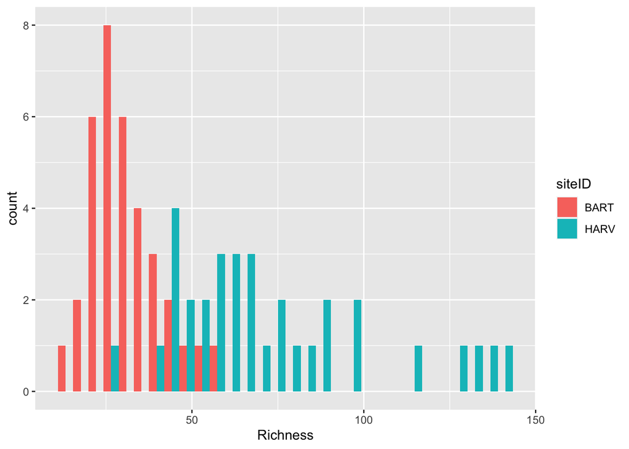

```r
ggplot(data = all_plants_summary) +
  geom_histogram(aes(x = Richness, fill = siteID), position = "dodge")
```

```r
t.test(all_plants_summary$Richness ~ all_plants_summary$siteID)
```

```
##
##  Welch Two Sample t-test
##
## data:  all_plants_summary$Richness by all_plants_summary$siteID
## t = -7.625, df = 38.692, p-value = 3.175e-09
## alternative hypothesis: true difference in means is not equal to 0
## 95 percent confidence interval:
##  -53.05435 -30.80365
## sample estimates:
## mean in group BART mean in group HARV
##           30.82857           72.75758
```

```r
length(unique(all_plants$plotID))
```

```
## [1] 68
```

```r
length(unique(all_plants$mainsubplotID))
```

```
## [1] 4
```